# **Predictive Lyric Analytics with NLP**

Harini

02/01/2021

## INTRODUCTION

Lyric analysis is slowly finding its way into data science communities as the possibility of predicting “Hit Songs” approaches reality. There are variety of machine learning (ML) classification algorithms to build models step-by-step that predict the genre of a song.The project work focus on variety of analytic tasks on a case study of musical lyrics by the legendary artist Prince, as well as other artists and authors. The project build models to classify songs into their associated genre and to investigate the possibility of using lyrics to determine commercial success.

## DATA INGESTION

[output not shown]

Then use unnest() from tidytext to create the tidy version with one word per record. ## DATA PREPROCESSING

Since the dataset has songs and book pages, I’ll refer to them each as a document. The features that are created based on documents and their associated metadata.There are artists and authors, I will refer to them as the source of each document.

```r
five_sources_data %>%
  group_by(genre, source) %>%
  summarise(doc_count = n()) %>%
  my_kable_styling("Training Dataset")
```

Training Dataset

| genre | source | doc_count |
| --- | --- | --- |
| christian | amy-grant | 279 |
| country | johnny-cash | 279 |
| data-science | machine_learning | 279 |
| hip-hop-rap | eminem | 279 |
| pop-rock | prince | 279 |

```r
five_sources_data_test %>%
  group_by(genre, source) %>%
  summarise(doc_count = n()) %>%
  my_kable_styling("Test Dataset")
```

Test Dataset

| genre | source | doc_count |
| --- | --- | --- |
| christian | chris-tomlin | 165 |
| country | patsy-cline | 165 |
| data-science | machine_learning_r | 165 |
| hip-hop-rap | jay-z | 165 |
| pop-rock | michael-jackson | 165 |

To see the genre, source, and the number of documents, the following chord diagram is a better way to view these relationships. There is a one-to-one relationship between source and genre because the artists are classified ; however, cross-over artists are very common.

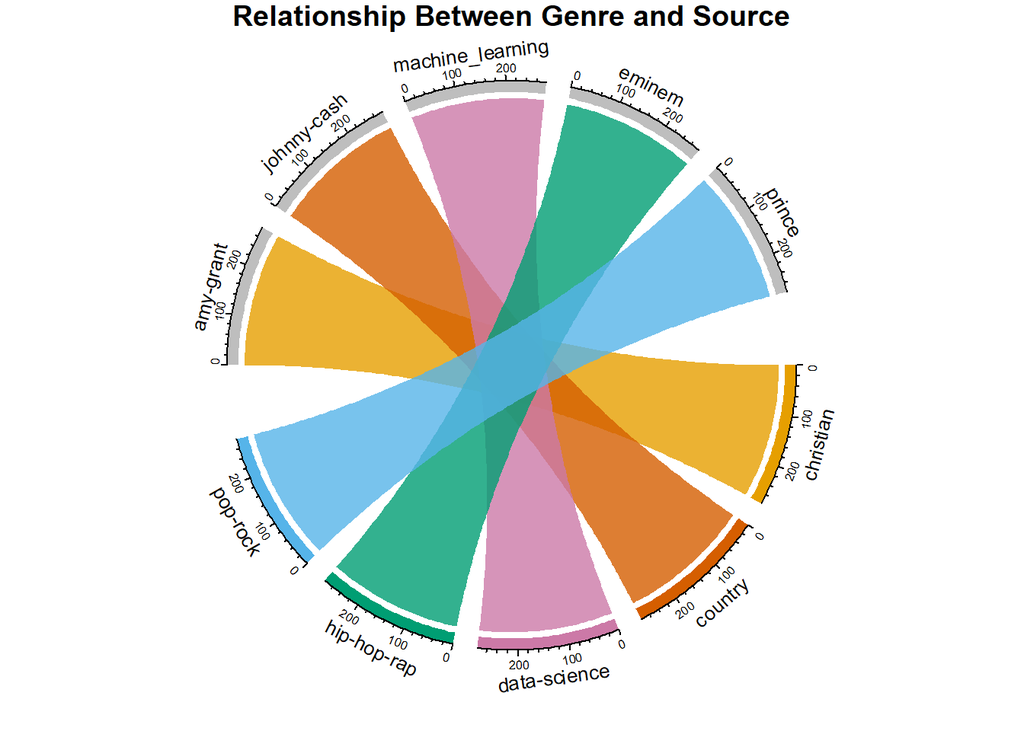

```r
#get SONG count per genre/source. Order determines top or bottom.
genre_chart <-  five_sources_data %>%
  count(genre, source)

circos.clear() #very important! Reset the circular layout parameters
#assign chord colors
grid.col = c("christian" = my_colors[1], "pop-rock" = my_colors[2],
             "hip-hop-rap" = my_colors[3], "data-science" = my_colors[4],
             "country" = my_colors[5],
             "amy-grant" = "grey", "eminem" = "grey",
             "johnny-cash" = "grey", "machine_learning" = "grey",
             "prince" = "grey")
# set the global parameters for the circular layout. Specifically the gap size
circos.par(gap.after = c(rep(5, length(unique(genre_chart[[1]])) - 1), 15,
                         rep(5, length(unique(genre_chart[[2]])) - 1), 15))

chordDiagram(genre_chart, grid.col = grid.col, transparency = .2)
title("Relationship Between Genre and Source")
```

This diagram would look like if there was not a one-to-one relationship.If prediction is made on genre based only on lyrics, would have gone wrong.

## Predict Genre

Think about the song and what makes one different from another, lyrically. A common theme in all music is repetition. Do some genres use repetition more than others? What about word length? Do some use larger or smaller words more often? What other factors drive to describe lyrics? Note that all of the variables listed above are quantitative features, (counts, lengths, etc.) based on words per song. But what about individual words specific to genres?

## Feature Engineering

Get the most common (frequently used) words per genre. Start by getting the total number of words per genre. Then group by words per genre and get a count of how often each word is used. Now select the top n most frequent words defined by the number_of_words variable. I came up with a total of 5500 as the most optimal number of words. Play around with this value and see how it impacts outcome. Many words are very common to more than one genre (such as time, life, etc.) and I have removed these words with the multi_genre variable below. This makes for a cleaner list of distinct words that create a better distinction between the sources.

```r
#play with this number until getting the best results for the model.
number_of_words = 5500

top_words_per_genre <- five_sources_tidy %>%
  group_by(genre) %>%
  mutate(genre_word_count = n()) %>%
  group_by(genre, word) %>%
  #note that the percentage is also collected, when really you
  #could have just used the count, but it's good practice to use a %
  mutate(word_count = n(),
         word_pct = word_count / genre_word_count * 100) %>%
  select(word, genre, genre_word_count, word_count, word_pct) %>%
  distinct() %>%
  ungroup() %>%
  arrange(desc(word_pct)) %>%
  top_n(number_of_words) %>%
  select(genre, word, word_pct)
#remove words that are in more than one genre
top_words <- top_words_per_genre %>%
  ungroup() %>%
  group_by(word) %>%
  mutate(multi_genre = n()) %>%
  filter(multi_genre < 2) %>%
  select(genre, top_word = word)

#create lists of the top words per genre
book_words <- lapply(top_words[top_words$genre == "data-science",], as.character)
country_words <- lapply(top_words[top_words$genre == "country",], as.character)
hip_hop_words <- lapply(top_words[top_words$genre == "hip-hop-rap",], as.character)
pop_rock_words <- lapply(top_words[top_words$genre == "pop-rock",], as.character)
christian_words <- lapply(top_words[top_words$genre == "christian",], as.character)
```

Think about each feature below and how it could vary according to the genre.country_word_count is merely a count of the top country words that appear in each song. Notice that I have assigned more weight to explicit and book words (see the 10 and 20 used in the sum() function). I did this because they are very distinctive and help to classify documents. Again, this was a trial and error process!

```r
features_func_genre <- function(data) {
  features <- data %>%
  group_by(document) %>%
  mutate(word_frequency = n(),
         lexical_diversity = n_distinct(word),
         lexical_density = lexical_diversity/word_frequency,
         repetition = word_frequency/lexical_diversity,
         document_avg_word_length = mean(nchar(word)),
         title_word_count = lengths(gregexpr("[A-z]\\W+",
                                             document)) + 1L,
         title_length = nchar(document),
         large_word_count =
           sum(ifelse((nchar(word) > 7), 1, 0)),
         small_word_count =
           sum(ifelse((nchar(word) < 3), 1, 0)),
         #assign more weight to these words using "10" below
         explicit_word_count =
          sum(ifelse(word %in% explicit_words$explicit_word,10,0)),
         #assign more weight to these words using "20" below
         book_word_count =
           sum(ifelse(word %in% book_words$top_word,20,0)),
         christian_word_count =
           sum(ifelse(word %in% christian_words$top_word,1,0)),
         country_word_count =
           sum(ifelse(word %in% country_words$top_word,1,0)),
         hip_hop_word_count =
           sum(ifelse(word %in% hip_hop_words$top_word,1,0)),
         pop_rock_word_count =
           sum(ifelse(word %in% pop_rock_words$top_word,1,0))
         ) %>%
  select(-word) %>%
  distinct() %>% #to obtain one record per document
  ungroup()

features$genre <- as.factor(features$genre)
return(features)
}
```

Now calling features() function for training and test datasets.

```r
train <- features_func_genre(five_sources_tidy)
test  <- features_func_genre(five_sources_test_tidy)
```

## Machine Learning Process

mlr (Machine Learning for R), is a framework that includes all of the frequently used machine learning algorithms. The ML process is simple: create a task, make a learner, train it, test it. Here are the steps :

Create the classifier task: declare the datasets and outcome (target) variable Normalize the data: pre-processing (scale and center) Create a list of learners: choose the learning algorithm(s) Choose a resampling method: choose a method to assess performance using a validation set during training Select the measures: create a list of measures such as accuracy or error rate Perform training/benchmarking: compare the results of the models based on the tasks and learners Tune the best model: choose the best performing learner and tune the hyperparameters Test on new data: run your model against data it has never seen before.

## The Classifier Task

A task is merely the dataset on which a learner learns. Since this is a classification problem, create a classification task by using makeClassifTask(). Specifying classification outcome variable, genre, by passing it as the target argument. There is also a dataset that uses only the basic quantitative features consisting of document summaries and counts. This task, task_train_subset is created without the genre word count features (i.e., country_word_count, pop_rock_word_count, etc.) to illustrate the importance of these contextual predictors in the final model. So using the dataset train[3:13] removes these variables.

```r
#create classification tasks to use for modeling

#this dataset does not include genre specific words
task_train_subset <- makeClassifTask(id = "Five Sources Feature Subset",
                                     data = train[3:13], target = "genre")
#create the training dataset task
task_train <- makeClassifTask(id = "Five Sources",
                              data = train[-c(1:2)], target = "genre")
#create the testing dataset task
task_test <- makeClassifTask(id = "New Data Test",
                             data = test[-c(1:2)], target = "genre")
```

## Normalize Data

It is simply a method of scaling data such that all the values are normalized between values of zero and one (or whatever values you pass). If some variables are much larger in value and are on a different scale than the others, they will throw off model by giving more weight to those variables. Normalization takes care of this problem. mlr provides a simple function called normalizeFeatures() for this step.

```r
#scale and center the training and test datasets
task_train_subset <- normalizeFeatures(task_train_subset, method = "standardize",
  cols = NULL, range = c(0, 1), on.constant = "quiet")

task_train <- normalizeFeatures(task_train, method = "standardize",
  cols = NULL, range = c(0, 1), on.constant = "quiet")

task_test <- normalizeFeatures(task_test, method = "standardize",
  cols = NULL, range = c(0, 1), on.constant = "quiet")
```

## Create a List of Learners

A learner in mlr is generated by calling makeLearner().We can obtain a list of possible classification algorithms by calling listLearners(“classif”)[c(“class”,“package”)].This shows the algorithms you have to choose from as well as their dependent packages (which may need to install separately).Currently there are over 80 classification learners in mlr.

```r
#create a list of learners using algorithms you'd like to try out
lrns = list(
makeLearner("classif.randomForest", id = "Random Forest", predict.type = "prob"),
makeLearner("classif.rpart", id = "RPART", predict.type = "prob"),
makeLearner("classif.xgboost", id = "xgBoost", predict.type = "prob"),
makeLearner("classif.kknn", id = "KNN"),
makeLearner("classif.lda", id = "LDA"),
makeLearner("classif.ksvm", id = "SVM"),
makeLearner("classif.naiveBayes", id = "Naive Bayes"),
makeLearner("classif.nnet", id = "Neural Net", predict.type = "prob")
)
```

## Resampling

It involves repeatedly drawing samples from a training set and refitting a model on each sample. This may allow you to obtain information not available from fitting the model only once with the original training data.k-fold cross validation indicated by the “CV” in the call to makeResampleDesc() which returns a resample description object (rdesc). This approach randomly divides the dataset into k groups (folds) of equal size. The first fold is used as a validation set, and the remaining folds are used for training. This is repeated k times on each of the folds. The error rate is captured for each iteration and averaged at the end.

```r
# n-fold cross-validation use stratify for categorical outcome variables
rdesc = makeResampleDesc("CV", iters = 10, stratify = TRUE)
```

## Performance Measures

The typical objective of classification is to obtain a high prediction accuracy and minimize the number of errors. Accuracy is the number of correct predictions from all predictions made. Confusion matrix to see how things were classified (predicted vs. actual).

```r
#let the benchmark function know which measures to obtain
#accuracy, time to train
meas = list(acc, timetrain)
```

## Train Models / Benchmark

Benchmark experiment in which different algorithms (learning methods) are applied to dataset. It will compare algorithms according to the specific measures of interest (i.e., accuracy).benchmark() to train your model and generate a BenchmarkResult object from which we can access the models and results. Take the dataset which does not include the genre-specific word counts. Pass to benchmark list of learners, the subset task, the resampling strategy (rdesc), and the list of measures we would like to see.

```
## [1] "BenchmarkResult"
```

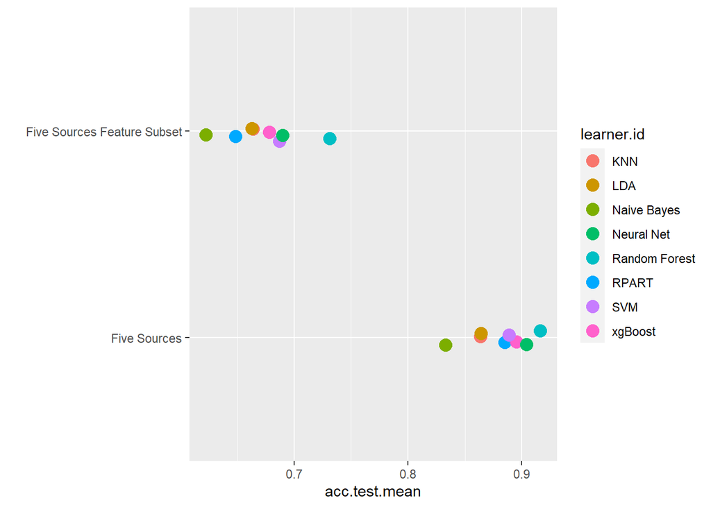

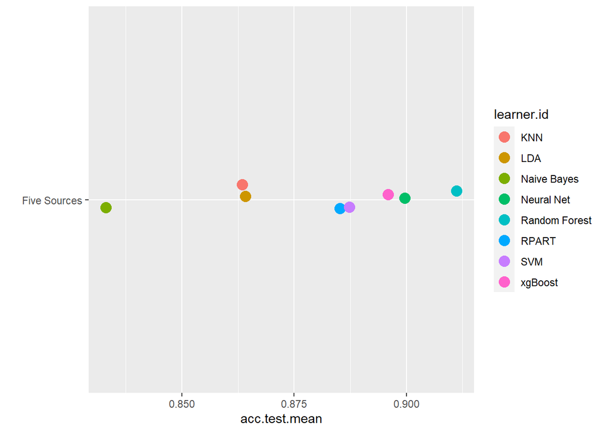

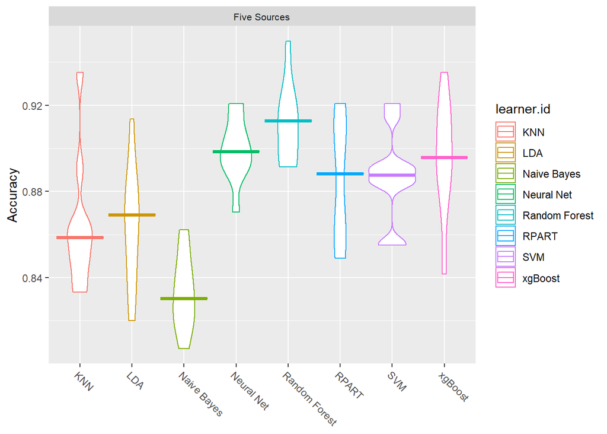

These boxplots show you the results for each method across several iterations performed by benchmarking.

Validation Set Model Comparison

| ModelType | Accuracy |
| --- | --- |
| Random Forest | 0.9111 |
| Neural Net | 0.8996 |
| xgBoost | 0.8959 |
| SVM | 0.8872 |
| RPART | 0.8852 |
| LDA | 0.8642 |
| KNN | 0.8634 |
| Naive Bayes | 0.8331 |

```r
predictions <- getBMRPredictions(bmr)

calculateConfusionMatrix(predictions$`Five Sources`$`Random Forest`)$result  %>%
  my_kable_styling("Random Forest Confusion Matrix: Rows are True, Columns are Predictions")
```

Random Forest Confusion Matrix: Rows are True, Columns are Predictions

|  | christian | country | data-science | hip-hop-rap | pop-rock | -err.- |
| --- | --- | --- | --- | --- | --- | --- |
| christian | 246 | 20 | 2 | 1 | 8 | 31 |
| country | 21 | 246 | 0 | 1 | 11 | 33 |
| data-science | 0 | 0 | 269 | 1 | 1 | 2 |
| hip-hop-rap | 5 | 5 | 0 | 256 | 13 | 23 |
| pop-rock | 20 | 8 | 0 | 6 | 244 | 34 |
| -err.- | 46 | 33 | 2 | 9 | 33 | 123 |

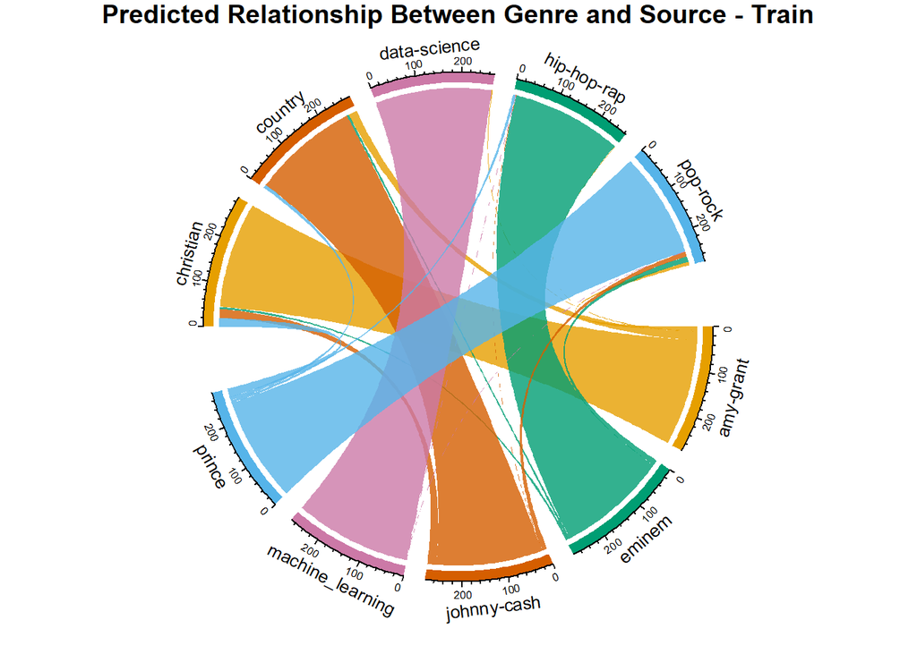

Now you can see how well you did on the training data. Once again the results are impressive. The smaller lines represent the misclassifications. First model data with simple models and analyze data for errors. These errors signify data points that are difficult to fit by a simple model. Then for later models, particularly focus on those hard to fit data to get them right. In the end, combine all the predictors by giving some weights to each predictor. ## Tune the model - xgBoost

```
## $booster
## [1] "gbtree"
##
## $nrounds
## [1] 19
##
## $max_depth
## [1] 4
##
## $min_child_weight
## [1] 2.102768
##
## $subsample
## [1] 0.6236946
##
## $colsample_bytree
## [1] 0.9520378
##
## $eta
## [1] 0.1259807
```

Examine the optimized parameters by looking at the output of tuneParams(). Now you want to create a new model using the tuned hyperparameters and then re-train on the training dataset.

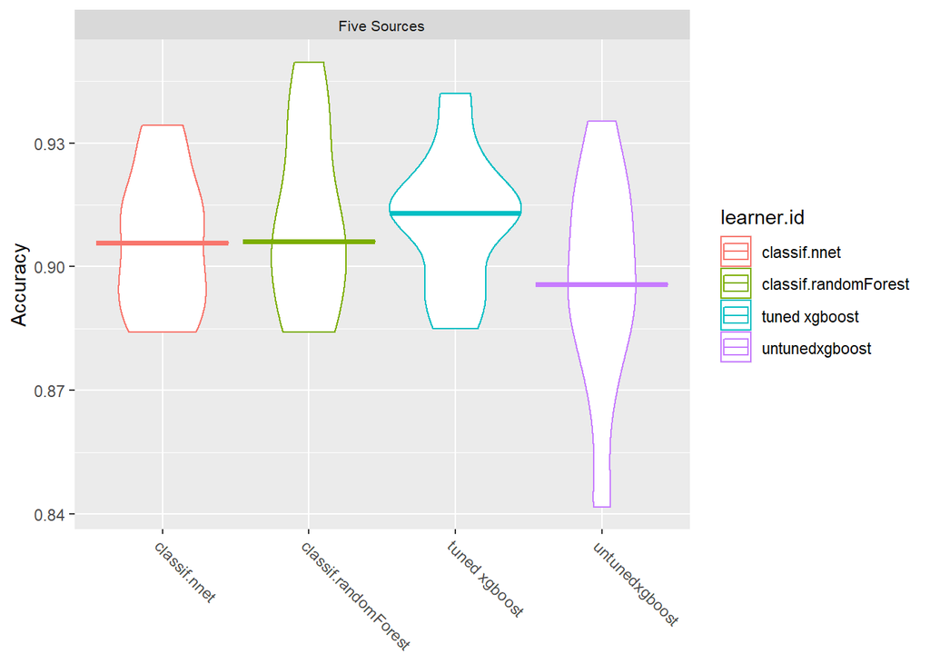

Validation Set Model Comparison

| ModelType | Accuracy |
| --- | --- |
| tuned xgboost | 0.9119 |
| classif.randomForest | 0.9112 |
| classif.nnet | 0.9061 |
| untunedxgboost | 0.8959 |

```
##      acc
## 0.631068
```

```
##       acc
## 0.6201456
```

TEST: xgBoost Confusion Matrix: Rows are True, Columns are Predictions

|  | christian | country | data-science | hip-hop-rap | pop-rock | -err.- |
| --- | --- | --- | --- | --- | --- | --- |
| christian | 54 | 26 | 1 | 45 | 39 | 111 |
| country | 25 | 69 | 1 | 29 | 41 | 96 |
| data-science | 0 | 0 | 163 | 1 | 0 | 1 |
| hip-hop-rap | 0 | 3 | 0 | 143 | 19 | 22 |
| pop-rock | 21 | 25 | 1 | 36 | 82 | 83 |
| -err.- | 46 | 54 | 3 | 111 | 99 | 313 |

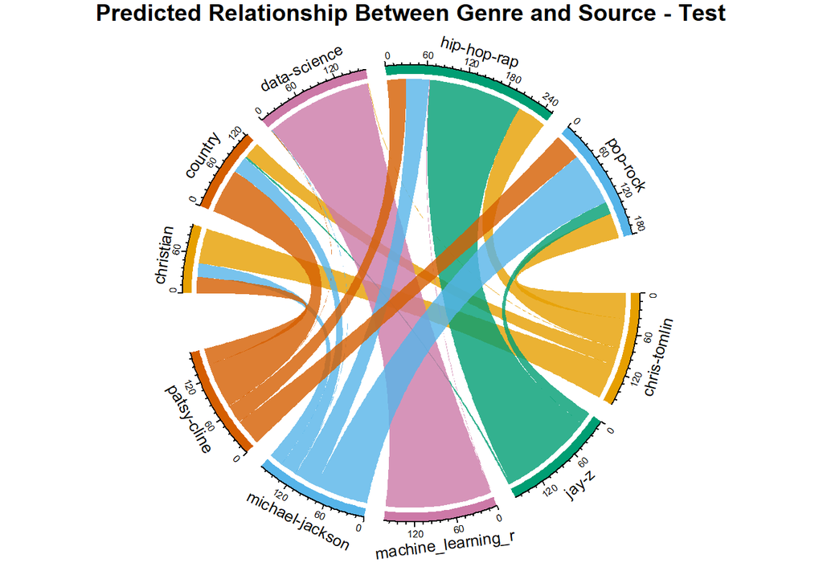

New chord diagram actually gives a more realistic version of the lyrical classification than shown in the original dataset! There actually isn’t a one-to-one relationship between artist, and genre in real life and that flexibility is built into model. ## Conclusion We have built a model to predict the genre of a song based entirely on lyrics. We used supervised machine learning classification algorithms and trained models on a set of five different artists and five different genres. By using the mlr framework, created tasks, learners and resampling strategies to train and then tune a model(s). Then ran the model against an unseen test dataset of different artists. we were able to identify which algorithms work better with the default settings, and eventually, predict the genre of new songs that our model has never seen.